# Power and Sample Size in Logistic Regression

Guanlan Xu, Scott Koeneman, Matthew Davis

May/09/2019

This paper is a summary of the results we found for our project on finding sample size for tests of significance in logistic regression. It is split into 3 principle sections: analytical methods, simulation methods, and case studies. In each, we take a look at different methods one can use when attempting to find sample size for tests of coefficients in logistic regression.

# Brief Introduction

## Definition of Power

Power is the probability of correctly rejecting a null hypothesis given that the alternative hypothesis is true. More precisely power is the probability that a statistic will fall into a critical rejection region defined by the Type-I error rate, given that statistic represents the true population parameter of interest.

For the normal distribution, this is the typical close-form power formula we’ve seen before. In the context of logistic regression, this is also the formula used to calculate power using the Wald Testing procedure, with $\mu$ values referring to the $\beta$ coefficient values.

$$1- \beta = \Phi\left(\frac{|\mu_0 - \mu_1|\sqrt{N}} {2\sigma} - \Phi^{-1}(1-\frac{\alpha}{2})\right)$$

Notice directional relationships from the equation: as sigma increases, power decreases. As n increases, power increases. As alpha increases, power increases. As the treatment effect (the absolute difference between $\mu_{0}$ and $\mu_{1}$) increases, so does power. These sorts of relationships hold for non-normal distributions as well.

For the LR Test, Given our model under null denoted as $M0$ and our model under the alternative $M1$ the power function can be expressed as below.
$$1- \beta = P\left( -2log(\frac{L(\hat{\theta_1})}{L(\hat{\theta_0})}) > \chi^2_{p-1} \mid \theta = \theta_1\right)$$

More generally
$$1- \beta = \gamma_{C(\theta)} = P_{\theta}\left([g(X_{1},...,X_{n})] \in C \mid \theta = \theta_1\right)$$

# 1. Analytical Methods For Wald Test

There are two common ways to calculate sample size. One method is to run a precision analysis because sample size is closly related to the standard error and thus would affect the range of confidence interval. Researchers can calculate sample size based on a predefined precision level. Another method is to do a power analysis. In statistics, power is defined as the probability of rejecting a false null hypothesis. Previous simulation studies have shown that power has a positive association with sample size as well as effect size. If we assume the test statistic follows a standard normal distribution, sample size can then be calculated by the general formula (shown below), based on a predefine power size ($1-\beta$) and effect size ($ES$).

$$n = (\frac{Z_{1-\alpha/2} - Z_{1-\beta} }{ES})^2$$

In the case of logistic regression, hypothesis can be tested by wald test, likelihood ratio test, or F test. Considering the simplisity and popularity of wald test, we will focus on the wald test here.

Below is the setup of wald test.

- Hypotheses: $H_0: \beta_1 = 0$ ; $H_1: \beta_1 = \beta_A$
- Test Statistic: $\frac{\hat \beta_A - \beta_0}{se(\hat \beta_1)} \sim Z$
- Effect Size: $\frac{\beta_A - \beta_0}{sd(\beta_1)}$

Since the test statistic follows a $z$ distribution, we can use the general sample size formula and plug in the effect size:

$$n = (\frac{Z_{1-\alpha/2} - Z_{1-\beta} }{ES})^2 = \frac{(Z_{1-\alpha/2} - Z_{1-\beta})^2 * var(\beta_1)}{(\beta_A)^2 }$$

Clearly, the difficulty is to find out the variance of the slope ($\beta_1$). One way to deal with this problem is to use fisher information matrix.

### Fisher Information Matrix Method

Assume the predictor variable $\mathbf{X}$ follows a normal distribution with mean equals to $\mu$ and variance equals to $\sigma^2$, if n is large, the maximum likelihood estimator of $\beta_i$ will follow a normal distribution, with mean equals to $\beta_i$ and variance equals to its inverse of fisher information matrix $\mathbf{I}^{-1}$.

In logistic regression, we know:

- $\theta = log(\frac{\pi}{1-\pi})$;
- $b(\theta) = log(1+e^\theta)$;
- $a(\phi) = \frac{1}{m}$.

Define: $\mathbf{W} = diag(\frac{1}{b''(\theta_i)(g'(\mu_i))^2}) = diag(\pi_i(1-\pi_i)) = diag(\frac{e^{\beta_0 + \beta_1X_i}}{(1+e^{\beta_0 + \beta_1X_i})^2})$

Then fisher information matrix is:

$$\mathbf{I}= X^TWX = \left[\begin{array}
{rr}
E(\frac{e^{\beta_0+\beta_1X}}{(1+e^{\beta_0+\beta_1X})^2}) & E(\frac{Xe^{\beta_0+\beta_1X}}{(1+e^{\beta_0+\beta_1X})^2}) \\
E(\frac{Xe^{\beta_0+\beta_1X}}{(1+e^{\beta_0+\beta_1X})^2}) & E(\frac{X^2 e^{\beta_0+\beta_1X}}{(1+e^{\beta_0+\beta_1X})^2})
\end{array}\right]$$

For simplification, we can denote each elements as $i_{00}$,$i_{01}$,$i_{10}$,$i_{11}$.

$$\mathbf{I} = \left[\begin{array}
{rr}
i_{00} & i_{01} \\
i_{10} & i_{11}
\end{array}\right]$$

If we take inverse of the matrix and the second diagnal element would be variance of slope.

$$var(\hat \beta_1) = \frac{i_{00}}{i_{00}i_{11}-i_{10}^2}$$

Now we can plug it into the sample size formula.

$$n = \frac{(i_{00}) *(Z_{1-\alpha/2} - Z_{1-\beta})^2 }{(i_{00}i_{11}-i_{10}^2)(\beta_A)^2 }$$

Still, from the formula, we can find that in order to solve sample size, we have to calculate each element in the fisher information matrix. Researchers have come up with two different ways.

1. Hermite Polynomial Approximation

This is a method mentioned in Grieve, A. et al.(2016). Since $\mathbf{X}$ follows a normal distribution, they re-wrote each element in the fisher information matrix as the form of expectation of a function of $\mathbf{X}$, utilizing the normal density function and then applied Hermite polynomial approximation to solve it.

$$\frac{1}{\sqrt(2\pi\sigma)}\int \frac{X^ke^{\beta_0+\beta_1X}}{(1+e^{\beta_0+\beta_1X})^2} e^{-\frac{1}{2 \sigma^2}(X-\mu)^2} dX (K = 0,1,2)$$

$$\sum_{i=1}^{N} \frac{W_i}{\sqrt \pi} \frac{(\sqrt{2}\sigma Z_i + \mu)^K e^{\beta_0+\beta_1(\sqrt{2}\sigma Z_i)+ \mu}}{(1+e^{\beta_0 + \beta_1(\sqrt{2}\sigma Z_i +\mu)})^2}$$
Here, $K$ is $0,1,2$, N is an integer selected by researcher. Bigger N generally gives more accurate result. Grieve, A. et al.(2016) used N = 20 in their paper because it is the maximum number provided by Abramowitz and Stegun(1984). $Z_i$ and $W_i$ are zeros and weights of Hermite polynomial approximation that can be found on published table.

2. Whittemoreâs Approximation

Whittemore(1981) developed a special case for low prevalence. If the prevalence is low, the probability of case ($P(Y=1)$) will be extremely small, and approach to 0. Therefore, the demoninator of logit (i.e., $P(Y=0)$) will be close to 1. As a result, the logistic model can be approximated by a log-linear model

$$\pi (Y=1 | \beta_0, \beta_1, X) = \frac{e^{\beta_0+\beta_1X}}{1+e^{\beta_0+\beta_1X}} \approx e^{\beta_0+\beta_1X}$$

This method greatly facilitated computation of fisher information matrix. The sample size formula given by this method is:

$$N = \frac{(Z_\alpha + e^{-\frac{\beta_1^2}{4}} Z_\beta)^2 } {e^{\beta_0}\beta_1^2} *
[1+2^{e ^ {\beta_0}} * \frac
{[1+(1+\beta_1^2)e^{\frac{5\beta_1^2}{4}}]}
{1+2e^{\beta_0}}]$$

### Two Sample T-test Method

1. Heieh et al.(1998)’s Approximation

Heieh et al.(1998) developed a sample size formula from a different angle. Instead of using fisher information matrix, they treated the test as a two sample T-test by assuming $X_1|Y=1 \sim N(m_1,\sigma_1)$, $X_2 | Y = 0 \sim N(m_2, \sigma_2)$, and $\sigma_1 = \sigma_2 = \sigma$. Define $\Delta$ is the difference between null hypothsised value and true value, then they obtained the sample size formula for equal sample size condition.

$$n = \frac{(Z_{1-\alpha/2}+ Z_{1-\beta})^2}{\frac{\Delta^2}{2(\sigma_1^2 + \sigma_2^2)}}$$

Considering that in logistic regression if $P(Y=1)$ and $P(Y=0)$ differs to each other, sample sizes of these two groups will be different, they multiplied a factor of $\frac{(K+1)^2}{4K}$ to the above formula for correction, where K is sample size ratio. In the case of logistic regression,$K = \frac{1-p}{p}$, and p is the probability evaluated at $x=0$ (i.e., $p = \frac{e^{\beta_0}}{1+e^{\beta_0}}$). The derivation is shown below.

$$n = \frac{(Z_{1-\alpha/2}+ Z_{1-\beta})^2}{\frac{\Delta^2}{2(\sigma_1^2 + \sigma_2^2)}} \frac{(K+1)^2}{4K} = \frac{\sigma^2 (Z_{1-\alpha/2}+ Z_{1-\beta})^2 \frac{(K+1)^2}{K}}{\Delta^2}$$

$$\frac{(K+1)^2}{K} = \frac{(\frac{1-p}{p} + \frac{p}{p})^2} {\frac{1-p}{p}} = \frac{1}{p(1-p)}$$

Considering that the slope is the change in log odds for every 1 unit increase of X, Heieh et al.(1998) further defined slope $\beta^*$as $\frac{\Delta}{\sigma}$, and finalized the sample size formula below:

$$n = \frac{(Z_{1-\alpha/2}+ Z_{1-\beta})^2}{p(1-p){\beta^*}^2}$$

2. Novikov et al.(2010)’s Modification

Novikov et al.(2010) commented that Heieh et al.(1998)’s method requires four assumptions and none of them actually hold in practice. Those four assumptions are:

- Conditional distributions of $X_1|Y=1$ and $X_2|Y=0$ are normally distributed.
- Variances of two groups are equal, i.e., $\sigma_1 = \sigma_2$.
- Slope equals to standardized difference in the conditional means, i.e.,$\frac{\Delta}{\sigma} = \beta^*$.
- Conditional distribution have zero skewness.

Thus, Novikov et al.(2010) used Schoutenâs sample size formula as modification. They broke the sample size into two parts $n_1$ and $n_0$. The final sample size is approximated by summing those two parts up.

$$n_1 = (Z_{1-\alpha/2}+ Z_{1-\beta})^2 \frac{(\tau + \gamma)S_1^2}{\gamma (m_1 - m_2)^2} + \frac{(\tau^2 + \gamma^3)Z_{1-\alpha/2}}{2 \gamma (\tau + \gamma)^2}$$

$$n_0 = \gamma n_1$$

$$n = n_1 + n_0$$
Where: $\gamma = \frac{ sample\, size\, of group \,0}{sample\,size\, of\, group\, 1}$; $\tau = \frac{sample \,variance \, of\, group\, 0}{sample \,variance \, of\, group \,1}$.

### Disadvantages of Analytical Approximation Methods

The disadvantages are very obvious.

1. As mentioned in title, these methods are all approximation methods. None of them can give accurate result. Even worse, those methods vary in their ability to determine accurately sample size. Simulation studies have shown that the hermite polynomial method tends to overpower by up to 16%. Whittemore(1981)’s method only works for pervalence that is no greater than 27%. Hsieh et al.(1998)’s method has 50% reduction in the targeted power. Novikov et al.(2010)’s method could underpower by 5% and may also overpower by 10%.
2. Those approximation formulas only takes one predictor varible so they can only deal with sample size calculation for simple logistic regression. Deriving formulas for multiple logistic regression will be a much more challenging job.

# 2. Simulations Techniques

While closed form solutions to solve for required sample size can be advantageous, most of these methods are limited in that they only work for simple logistic regression. If we desire to find the sample size needed to power a study using a model with more than one predictor, interactions, or higher-order polynomial terms, a different method is needed. A powerful method used in far more situations than just logistic regression is simulation. The basis of this method is to simulate samples from our generating model, and perform hypothesis tests on these samples to see how often one rejects the null given a certain data generating mechanism, and thus calculate the power.

This project focused on the “Binary Search Algorithm”, a general method for finding power that can be applied in many different contexts. The general form of the algorithm is to:

1. Specify the model and data generating mechanism
2. Specify lower and upper bound on sample size, and set other parameters
3. Calculate power for the lower and upper bounds
4. Calculate power for the midpoint between the bounds
5. See which bisection contains desired power, repeat with this subsection
6. Stop when an n is found with suitable power

While this method is generally applicable to models of many different forms, in our case the algorithm was applied to a logistic regression model. The R script used to implement the code can be found in the repository under filename “logitpowerexample.R”. A more detail description of each step of the algorithm is given below.

### Step 1

For this step, the model must be defined, and true values for the coefficients of the regression model must be specified. Note that one must specify the values of all coefficients, not just the one being tested for significance. Additionally, some kind of assumptions need to be made about the predictors, so that sets of predictors can be generated. When little is known about the predictors, broad distributional assumptions using a normal or uniform (for continuous predictors) or multinomial (for categorical) can be used. However, if data from a pilot or previous study exists, this should be taken into account when simulating predictors, either by resampling of this data or using its distribution to generate new sets of predictors.

### Step 2

For this step, the lower and upper bound on sample size needs to be specified. The range of these bounds needs to be wide enough to capture the true n that we are searching for, or else the algorithm will not converge. However, a narrower range will result in faster computation. Other parameters that need to be defined are the desired power of the study, the desired type I error rate, and which predictor(s) are of interest in hypothesis testing for significance. Furthermore, a tolerance needs to be set, with the tolerance being an amount of deviation away from the desired power that is acceptable. This is necessary, as it is highly unlikely that an n exists that gives the exact desired power.

### Step 3

At this step, the power for the lower bound and upper bound are calculated. This is accomplished by first generating n sets of predictors from the generating mechanism. These predictors are then used, with the true model coefficients, to generate the probability of success using the regression model, and this probability of success is used to perform a Bernoulli trial to generate an outcome. We now have a set of predictors, with outcomes, and we use these to fit a model. With the fitted model, we perform the hypothesis test for significance of our coefficient of interest. Note that this can be any hypothesis test, and we are not limited to just the Wald test. We repeat this procedure many times, for both the lower and upper bound on n, and find our proportion of rejections for each. This is our estimate of power for each sample size.

### Step 4

For this step, we find the midpoint between the lower and upper bounds. Note that this value may not be an integer, and thus may have to be rounded to be a valid sample size. Once this value is found, we repeat the above procedure to find the power at this sample size. Note that now, we have bisected the possible values of n into two subsections.

### Step 5

We now look at the two bisections we have created. If the desired power lies above that of the midpoint n and below that of the upper bound, we choose this bisection, and our midpoint n becomes our new upper bound. If the opposite is true, and the desired power lies in the lower bisection, we make midpoint n our new upper bound. Once this new lower/upper bound is chosen, we see which of the bounds has a power closer to our desired power; this is our “best estimate” for sample size at the moment.

### Step 6

With our new lower and upper bounds, we repeat steps 4 and 5 many times, and iterate until the power of our “best guess” for n is within the tolerance of our desired power. Convergence may take quite some time, depending on the initial guesses for the lower and upper bounds, but provided the true n is within these bounds and the tolerance is liberal enough, the algorithm should converge and output a result.

### Method Overview

The binary search algorithm has several strengths. Chief among them is that the method can be used for any model, no matter how complex, and any test of significance. All that needs to be changed is the code used to implement these parts of the simulation. Additionally, with a liberal tolerance, an estimate for sample size can be obtained when no perfect sample size exists, which in applied settings is often good enough. Lastly, the algorithm can easily be tweaked to accommodate a different alpha level or desire power, and still performs well.

However, the method is not without its drawbacks. A major weakness of this method is that its versatility comes at a very high computational cost. Since a wide initial range is needed to guarantee convergence, this can often result in many, many iterations being needed to converge, and the more complex the model is, the more complex each iteration will be. The simple model used in the example code took 2-3 minutes to converge to a solution, despite being a relatively straightforward model and data generating mechanism. Additionally, this method requires specification of the effect sizes of all model coefficients, not just the one of interest. This can prove difficult when little is known about the effects of these coefficients, although previous studies and pilot studies can be used for reference if available. The predictors also need to be generated, which again, lacking prior data, can be hard to make accurate assumptions about. Lastly, while this method is very general, more specialized methods for certain study designs exist, and may be better-suited to the data in question.

# 3. Other Methods and Case Study

### Normal Distribution Power Simulations

The following functions modify the hard-coded simulation taken from EGAP. The EGAP function simulates data from the normal distribution with the given set parameters, and then calculates the probability of (correctly) rejecting the null hypothesis.

### Simple power simulation:

Below is the most basic function, SimplePowerSim(), which examines directional relationships with power for a 1 predictor case.

```r
SimplePowerSim <- function(possible.ns,alpha,sims,mu_null,sigma,treat_effect){
    #' Computes the power of a normal distribution for a single covariate.
    #'
    #' Args:
    #'   possible.ns: Vector of sample sizes to simulate
    #'   alpha: Type I error rate
    #'   sims: Number of simulations to run per sample size
    #'   mu_null: Null hypothesis of treatment effect
    #'   sigma: Population standard deviation
    #'   treat_effect: Difference between mu_null parameter
    #'                 and hypothesized alternative mu_alt
    #'
    #' Returns A vector containing:
    #'    powers: Mean power across simulations at each sample size
    #'
  powers <- rep(NA, length(possible.ns))
  for (j in 1:length(possible.ns)){
    N <- possible.ns[j]                                # Pick the jth value for sample size

    significant.experiments <- rep(NA, sims)           # Empty object to count significant experiments

    #### Inner loop to conduct experiments "sims" times over for each N ####
    for (i in 1:sims){
      Y0 <-  rnorm(n=N, mean=mu_null, sd=sigma)        # vector of simulated outcomes under null
      tau <- treat_effect                              # Hypothesize treatment effect (mu alt)
      Y1 <- Y0 + tau                                   # vector of simulated outcomes under alt
      Z.sim <- rbinom(n=N, size=1, prob=.5)            # Do a random assignment of treatments
      Y.sim <- Y1*Z.sim + Y0*(1-Z.sim)                 # Reveal outcomes according to assignment
      fit.sim <- lm(Y.sim ~ Z.sim)                     # Do analysis (simple linear regression)
      p.value <- summary(fit.sim)$coefficients[2,4]    # Extract p-values
      significant.experiments[i] <- (p.value <= alpha) # Determine significance according to p <= alpha
    }

    powers[j] <- mean(significant.experiments)         # store average success rate (power) for each N
  }
  return(powers)                                       # returns the powers as a vector
}
```

Below, we will examine the relationship between effect size and power. As we would expect, effect size and power have a direct relationship.

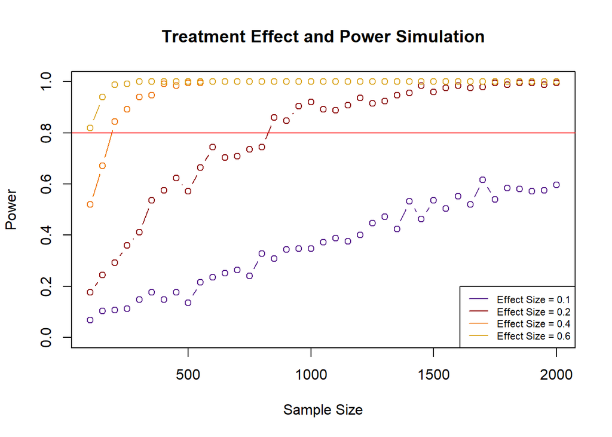

```r
possible.ns <- seq(from=100, to=2000, by=50)                #Specify sample sizes to simulate
effectsize <- c(.1,.2,.4,.6)                                #Specify effect sizes to simulate
colvec <- c("purple4","red4", "darkorange2", "goldenrod")   #Colors for corresponding effect sizes

## Run four simulations with the below parameters, differing only in treatment effect
## Recall: SimplePowerSim <- function(possible.ns,alpha,sims,mu_null,sigma,treat_effect)
Y1 <- SimplePowerSim(possible.ns,.05,250,0,1,effectsize[1])
Y2 <- SimplePowerSim(possible.ns,.05,250,0,1,effectsize[2])
Y3 <- SimplePowerSim(possible.ns,.05,250,0,1,effectsize[3])
Y4 <- SimplePowerSim(possible.ns,.05,250,0,1,effectsize[4])

## Plot our results ##
ymat <- cbind(Y1,Y2,Y3,Y4)
for(i in 1:4){
  if(i == 1){
    plot(possible.ns,
         ymat[,i],
         ylim=c(0,1),
         col = colvec[i],
         type = "b",
         xlab = "Sample Size",
         ylab = "Power",
         main = "Treatment Effect and Power Simulation")
  } else{
    points(possible.ns,
           ymat[,i],
           ylim = c(0,1),
           col = colvec[i],
           type = "b")
  }
}
abline(h = .8, col = "red")
legend("bottomright",
       legend = c(paste0("Effect Size = ", effectsize[1]),
                  paste0("Effect Size = ", effectsize[2]),
                  paste0("Effect Size = ", effectsize[3]),
                  paste0("Effect Size = ", effectsize[4])),
       col = colvec, lty = 1, cex = .7)
```

We will repeat the process above by examining the relationship between sigma and power. As we would expect, sigma and power have an inverse relationship.

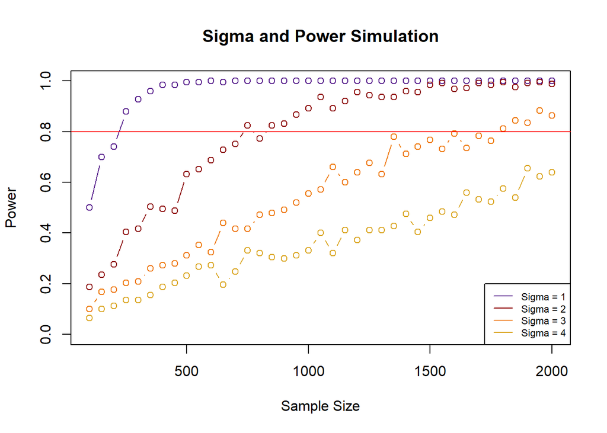

```r
possible.ns <- seq(from=100, to=2000, by=50)                #Specify sample sizes to simulate
sigmavec <- c(1, 2, 3, 4)                                   #Specify sigmas to simulate
colvec <- c("purple4","red4", "darkorange2", "goldenrod")   #Colors for corresponding effect sizes

## Run our simulations
## Recall: SimplePowerSim <- function(possible.ns,alpha,sims,mu_null,sigma,treat_effect) ##
Y1 <- SimplePowerSim(possible.ns,.05,250,0,sigmavec[1],.4)
Y2 <- SimplePowerSim(possible.ns,.05,250,0,sigmavec[2],.4)
Y3 <- SimplePowerSim(possible.ns,.05,250,0,sigmavec[3],.4)
Y4 <- SimplePowerSim(possible.ns,.05,250,0,sigmavec[4],.4)

## plot our results ##
ymat <- cbind(Y1,Y2,Y3,Y4)
for(i in 1:4){
  if(i == 1){
    plot(possible.ns,
         ymat[,i],
         ylim=c(0,1),
         col = colvec[i],
         type = "b",
         xlab = "Sample Size",
         ylab = "Power",
         main = "Sigma and Power Simulation")
  } else{
    points(possible.ns,
           ymat[,i],
           ylim = c(0,1),
           col = colvec[i],
           type = "b")
  }
}
abline(h = .8, col = "red")
legend("bottomright",
       legend = c(paste0("Sigma = ", sigmavec[1]),
                  paste0("Sigma = ", sigmavec[2]),
                  paste0("Sigma = ", sigmavec[3]),
                  paste0("Sigma = ", sigmavec[4])),
       col = colvec, lty = 1, cex = .7)
```

Below, we will examine how alpha affects power. As we’ve noted previously, alpha and power have a direct relationship.

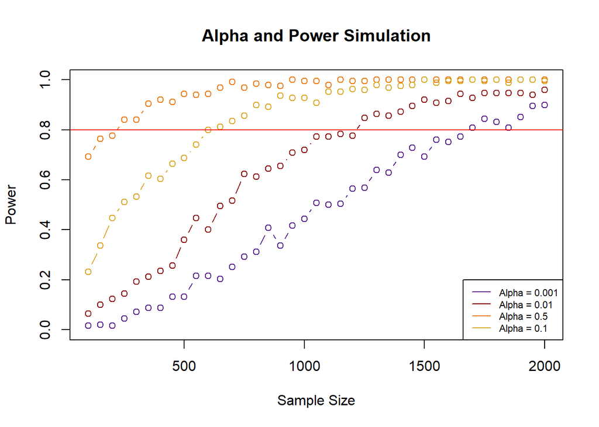

```r
possible.ns <- seq(from=100, to=2000, by=50)                #Specify sample sizes to simulate
alphavec <- c(.001, .01, .5, .1)                            #Specify vector of alphas to simulate
colvec <- c("purple4","red4", "darkorange2", "goldenrod")   #Colors for corresponding effect sizes

## Run our simulations ##
## Recall: SimplePowerSim <- function(possible.ns,alpha,sims,mu_null,sigma,treat_effect) ##
Y1 <- SimplePowerSim(possible.ns,alphavec[1],250,0,1,.2)
Y2 <- SimplePowerSim(possible.ns,alphavec[2],250,0,1,.2)
Y3 <- SimplePowerSim(possible.ns,alphavec[3],250,0,1,.2)
Y4 <- SimplePowerSim(possible.ns,alphavec[4],250,0,1,.2)

## Plot our results ##
ymat <- cbind(Y1,Y2,Y3,Y4)
for(i in 1:4){
  if(i == 1){
    plot(possible.ns,
         ymat[,i],
         ylim=c(0,1),
         col = colvec[i],
         type = "b",
         xlab = "Sample Size",
         ylab = "Power",
         main = "Alpha and Power Simulation")
  } else{
    points(possible.ns,
           ymat[,i],
           ylim = c(0,1),
           col = colvec[i],
           type = "b")
  }
}
abline(h = .8, col = "red")
legend("bottomright",
       legend = c(paste0("Alpha = ", alphavec[1]),
                  paste0("Alpha = ", alphavec[2]),
                  paste0("Alpha = ", alphavec[3]),
                  paste0("Alpha = ", alphavec[4])),
       col = colvec, lty = 1, cex = .7)
```

Recall from illustration above that variance and power have an inverse relationship; thus, increasing the number of parameters in our model will decrease our variance and increase our power, all else held constant. Intuitively, adding more covariates is like “controlling” for more predictors, as it removes external noise caused by covariates not of interest.

While the below examples offer a straightforward illustration, this does depend on the context of the analysis though; if our model radically changes based on which covariates are included, than this phenomenon will not be consistent. We will examine this more closely later on with case-control power simulations.

### Control for covariates:

This power simulation will demonstrate how controlling for an external ordinal covariate (ie gender) as well as a continous covariate (ie age) will help increse our power for our treatment parameter of interest.

```r
# Ensure that cov1 is a categorical variable with ordinal structure
# cov2 is continuous
CovariatePowerSim <- function(possible.ns, alpha, sims, mu_null, sigma,
                              treat_effect, cov1effect, cov2effect,
                              cov1pop, cov2pop){
    #' Computes the power of a normal distribution controlling for 1 ordinal 1 continous covariate
    #'
    #' Args:
    #'   possible.ns: Vector of sample sizes to simulate
    #'   alpha: Type I error rate
    #'   sims: Number of simulations to run per sample size
    #'   mu_null: Null hypothesis of treatment effect
    #'   sigma: Population standard deviation
    #'   treat_effect: Difference between mu_null parameter
    #'                 and hypothesized alternative mu_alt
    #'   cov1ffect: effect size of categorical covariate
    #'   cov2effect: effect size of continous covariate
    #'   cov1pop: simulated categorical population
    #'   cov2pop: simulated continous population
    #'
    #' Returns A matrix containing:
    #'    powers: Mean power across simulations (not controlling for covariates)
    #'    powers.cov: Mean power across simulations (controlling for covariates)
    #'

  ## Define the ordinal structure for the categorical variable ##
  categories <- unique(cov1pop)
  for(k in 0:(length(categories) - 1)){
    names(categories)[k+1] <- k
  }

  ## Assign a proportional effect for each category level ##
  for(m in 1:length(cov1pop)){
    for(n in 1:length(categories)){
      if(cov1pop[m] == categories[n]){
        cov1pop[m] <- as.numeric(names(categories)[n])
      }
    }
  }

  powers <- rep(NA, length(possible.ns))               # Vector to hold power sims
  powers.cov <- rep(NA, length(possible.ns))           # Need a second empty vector

  for (j in 1:length(possible.ns)){
    N <- possible.ns[j]                                # Pick the jth value for N

    significant.experiments <- rep(NA, sims)           # Empty object to count significant experiments
    significant.experiments.cov <- rep(NA, sims)       # Need a second empty vector here too

    #### Inner loop to conduct experiments "sims" times over for each N ####
    for (i in 1:sims){

      cov1vec <- sample(cov1pop, size = N)       # samples from our first covariate population
      cov2vec <- sample(cov2pop, size = N)       # samples from our second covariate population

      Y0 <- cov1effect*(as.numeric(cov1vec)) + cov2effect*cov2vec +
            rnorm(n=N, mean=mu_null, sd=sigma)

      ## This is all the same as with SimplePowerSim() ##
      tau <- treat_effect
      Y1 <- Y0 + tau
      Z.sim <- rbinom(n=N, size=1, prob=.5)
      Y.sim <- Y1*Z.sim + Y0*(1-Z.sim)
      fit.sim <- lm(Y.sim ~ Z.sim)

      ## This is the novel analysis -- including two covariates to increase precision ##
      fit.sim.cov <- lm(Y.sim ~ Z.sim + cov1vec + cov2vec)

      ## extract p-values for both models and calculate significance ##
      p.value <- summary(fit.sim)$coefficients[2,4]
      p.value.cov <- summary(fit.sim.cov)$coefficients[2,4]
      significant.experiments[i] <- (p.value <= alpha)
      significant.experiments.cov[i] <- (p.value.cov <= alpha)
    }

    ### store average success rate (power) for each N ###
    powers[j] <- mean(significant.experiments)
    powers.cov[j] <- mean(significant.experiments.cov)
  }

  powermat <- cbind(powers,powers.cov)                 # returns the powers in matrix form
  return(powermat)                                     # columns are uncontrolled vs. controlled
}
```

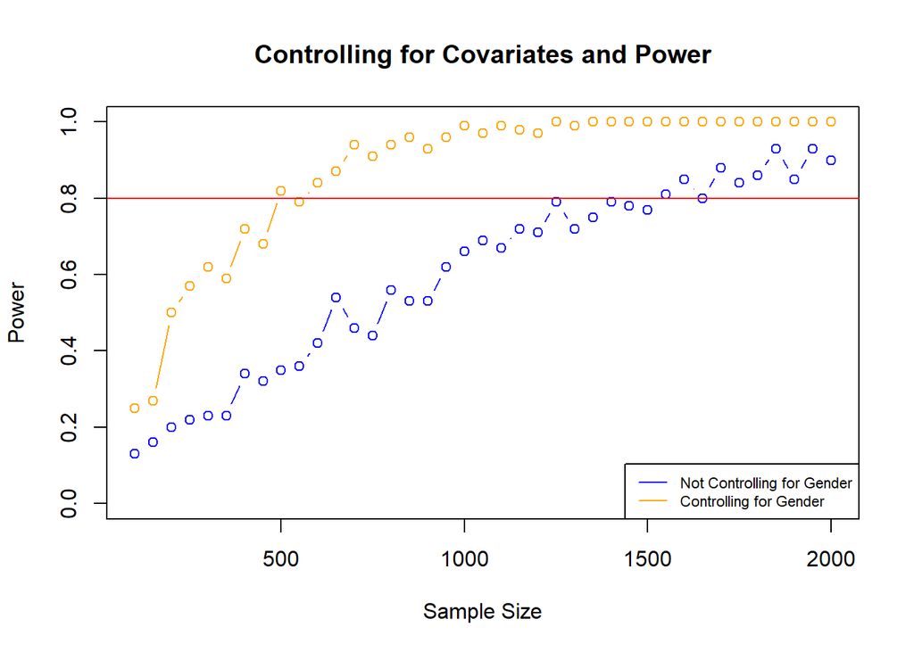

```r
possible.ns <- seq(from=100, to=2000, by=50)
N <- max(possible.ns)
colvec <- c("blue", "orange")

gender <- c(rep("F", 2*N), rep("M", 2*N), rep("0", 2*N))        # Generates a 3-level "gender" population
age <- sample(x=18:65, size= 10*N, replace=TRUE)                # Generates our "age" population
Ymat <- CovariatePowerSim(possible.ns = possible.ns,
                          alpha = .05,
                          sims = 100,
                          mu_null = 100,
                          sigma = 20,
                          treat_effect = 5,
                          cov1effect = 10,
                          cov2effect = 2,
                          cov1pop = gender,
                          cov2pop = age)

plot(possible.ns,
     Ymat[,1],
     ylim=c(0,1),
     col = colvec[1],
     type = "b" ,
     ylab = "Power",
     xlab = "Sample Size",
     main = "Controlling for Covariates and Power")
points(possible.ns,
       Ymat[,2],
       col=colvec[2],
       type = "b")
abline(h = .8, col = "red")
legend("bottomright",
       legend = c("Not Controlling for Gender", "Controlling for Gender"),
       col = colvec,
       lty = 1,
       cex = .7)
```

### Multiple treatments:

Below, we are modifying the above function to test multiple treatments of interest while also controlling for covariates.

```r
#install.packages("randomizr")
library(randomizr)

MultipleTreatmentPowerSim <- function(possible.ns, alpha, sims,
                                      mu_null, sigma, t1effect, t2effect,
                                      cov1effect, cov2effect, cov1pop, cov2pop){
    #' Computes the power of multiple treatments distributed normally while
    #'    controlling for 1 ordinal 1 continous covariate.
    #'
    #' Args:
    #'   possible.ns: Vector of sample sizes to simulate
    #'   alpha: Type I error rate
    #'   sims: Number of simulations to run per sample size
    #'   mu_null: Null hypothesis of treatment effect
    #'   sigma: Population standard deviation
    #'   t1effect: Difference between mu_null parameter
    #'                 and hypothesized alternative mu_alt for treatment 1
    #    t2effect: Difference between mu_null parameter
    #'                 and hypothesized alternative mu_alt for treatment 2
    #'   cov1ffect: effect size of categorical covariate
    #'   cov2effect: effect size of continous covariate
    #'   cov1pop: simulated categorical population
    #'   cov2pop: simulated continous population
    #'
    #' Returns A matrix containing:
    #'    power.atleastone: Mean power comparing either treatment effect vs. control
    #'    power.bothtreatments: Mean power comparing both treatments vs. control
    #'    power.fullranking: Mean power comparing treatment 1 vs. treatment 2
    #'

  ## Define the ordinal structure for the categorical variable ##
  categories <- unique(cov1pop)
  for(k in 0:(length(categories) - 1)){
    names(categories)[k+1] <- k
  }

  ## Assign a proportional effect for each category ##
  for(m in 1:length(cov1pop)){
    for(n in 1:length(categories)){
      if(cov1pop[m] == categories[n]){
        cov1pop[m] <- as.numeric(names(categories)[n])
      }
    }
  }


  power.atleastone <- rep(NA, length(possible.ns))
  power.bothtreatments <- rep(NA, length(possible.ns))
  power.fullranking <- rep(NA, length(possible.ns))

  #### Outer loop to vary the number of subjects ####
  for (j in 1:length(possible.ns)){
    N <- possible.ns[j]
    p.T1vsC <- rep(NA, sims)
    p.T2vsC <- rep(NA, sims)
    p.T2vsT1 <- rep(NA, sims)
    c.T1vsC <- rep(NA, sims)
    c.T2vsC <- rep(NA, sims)
    c.T2vsT1 <- rep(NA, sims)
    #### Inner loop to conduct experiments "sims" times over for each N ####
    for (i in 1:sims){

      cov1vec <- sample(cov1pop, size = N)       # samples from our first covariate population
      cov2vec <- sample(cov2pop, size = N)       # samples from our second covariate population

      Y0 <- cov1effect*(as.numeric(cov1vec)) + cov2effect*cov2vec +
            rnorm(n=N, mean=mu_null, sd=sigma)

      tau_1 <- t1effect
      tau_2 <- t2effect
      Y1 <- Y0 + tau_1
      Y2 <- Y0 + tau_2
      Z.sim <- complete_ra(N=N, num_arms=3)      #randomly assigns treatment groups
      Y.sim <- Y0*(Z.sim=="T3") + Y1*(Z.sim=="T1") + Y2*(Z.sim=="T2")
      frame.sim <- data.frame(Y.sim, Z.sim, cov1vec, cov2vec)
      fit.T1vsC.sim <- lm(Y.sim ~ (Z.sim=="T1") + cov1vec + cov2vec, data=subset(frame.sim, Z.sim!="T2"))
      fit.T2vsC.sim <- lm(Y.sim ~ (Z.sim=="T2") + cov1vec + cov2vec, data=subset(frame.sim, Z.sim!="T1"))
      fit.T2vsT1.sim <- lm(Y.sim ~ (Z.sim=="T2") + cov1vec + cov2vec, data=subset(frame.sim, Z.sim!="T3"))

      ### Need to capture coefficients and pvalues (one-tailed tests, so signs are important)
      c.T1vsC[i] <- summary(fit.T1vsC.sim)$coefficients[2,1]
      c.T2vsC[i] <- summary(fit.T2vsC.sim)$coefficients[2,1]
      c.T2vsT1[i] <- summary(fit.T2vsT1.sim)$coefficients[2,1]
      p.T1vsC[i] <- summary(fit.T1vsC.sim)$coefficients[2,4]
      p.T2vsC[i] <- summary(fit.T2vsC.sim)$coefficients[2,4]
      p.T2vsT1[i] <- summary(fit.T2vsT1.sim)$coefficients[2,4]
    }

    #Notice below how the bonferroni correction is really alpha/2 for each treatment T1 and T2
    #Testing one treatment gives a baseline and T1 so we divide by 1
    #Testing two treatments gives us a baseline and T1 and T2 so we divide by 2
    power.atleastone[j] <- mean(c.T1vsC>0 & c.T2vsC>0 & (p.T1vsC < alpha/2 | p.T2vsC < alpha/2))
    power.bothtreatments[j] <- mean(c.T1vsC>0 & c.T2vsC>0 & p.T1vsC < alpha/2 & p.T2vsC < alpha/2)
    power.fullranking[j] <- mean(c.T1vsC>0 & c.T2vsC>0 & c.T2vsT1 > 0 & p.T1vsC < alpha/2 & p.T2vsT1 < alpha/2)
  }

  powermat <- cbind(power.atleastone, power.bothtreatments, power.fullranking)
  return(powermat)
}
```

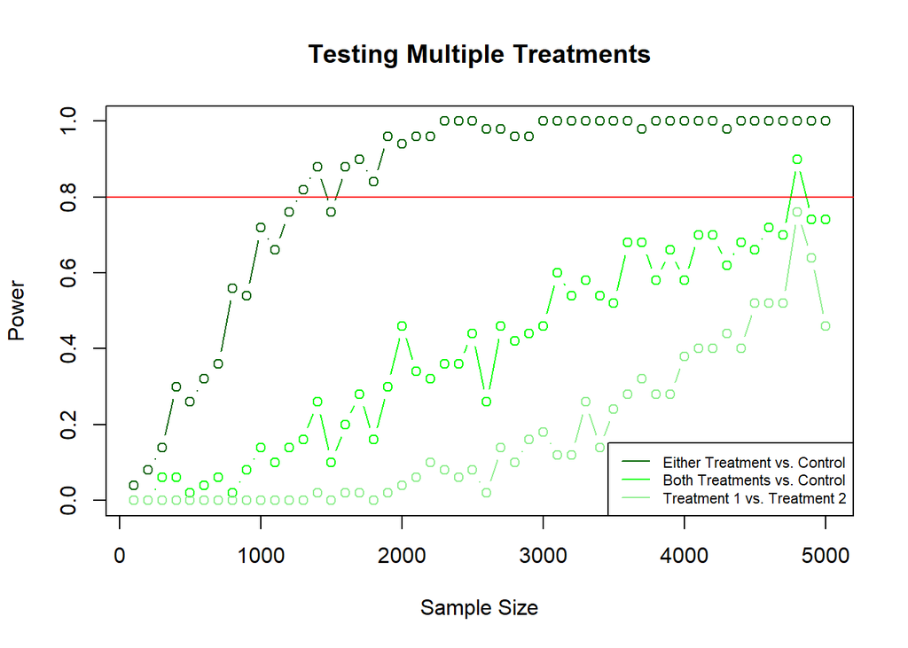

```r
possible.ns <- seq(from=100, to=5000, by=100)
colvec <- c("dark green", "green", "light green")
N <- max(possible.ns)
gender <- c(rep("F", 2*N), rep("M", 2*N), rep("0", 2*N))
age <- sample(x=18:65, size= 10*N, replace=TRUE)

mat <- MultipleTreatmentPowerSim(possible.ns = possible.ns,
                                 alpha = .01,
                                 sims = 50,
                                 mu_null = 60,
                                 sigma = 20,
                                 t1effect = 2.5,
                                 t2effect = 5,
                                 cov1effect = 2.5,
                                 cov2effect = 5,
                                 cov1pop = gender,
                                 cov2pop = age)

plot(possible.ns, mat[,1],
     ylim=c(0,1),
     type = "b",
     xlab = "Sample Size",
     ylab = "Power",
     col = colvec[1],
     main = "Testing Multiple Treatments")
points(possible.ns, mat[,2], col= colvec[2], type = "b")
points(possible.ns, mat[,3], col= colvec[3], type = "b")
abline(h = .8, col = "red")
legend("bottomright", legend = c("Either Treatment vs. Control",
                                 "Both Treatments vs. Control",
                                 "Treatment 1 vs. Treatment 2"),
            col = colvec, lty = 1, cex = .7)
```

# ccPower() Simulations

### Documentation:

https://rdrr.io/cran/osDesign/man/ccPower.html

The above simulations illustrate power for the normal distribution; what about for logistic regression? The below function ccPower() obtained from the osDesign package will conduct a power simulation for Logistic regression in the context of a Case-Control scenario.

Here is a summary of the most important parameters we will customize:

B = number of simulations to run at each sample size

betaTruth = coefficients to be inputted (use from glm() or manually encoded)

X = design matrix to be constructed manually

N = a vector of observed number of observations per design matrix row (a vector of 1s for ungrouped data)

r = ratio of controls/cases

nCC = a vector for the range of sample sizes to simulate

betaNames = a vector of names for the betaTruth coefficients, minus the intercept

alpha = Type I error rate

We will use alpha = .1, B = 100, and nCC = seq(from=50, to=500, by=20) unless otherwise noted.

The function will return:

1. A vector of coefficients for the beta terms
2. a matrix of power values with rownames referring to sample sizes, columns to predictor variables, and table entries as % hypothesis rejected (power).
3. failed: a vector of number of datasets that were excluded from power calculations.

When we run power simulations before an experiment or prospective study, we get to hypothesize treatment effects and decide how large of a sample we need to achieve the power we desire.

However, in a case-control study, we do not have the luxury of controlling our sample sizes; the number of cases and controls are fixed. In a sense, our study has been ‘completed’, and whatever sample size we have we are stuck with. We may ask, “What if our experiment had the same treatment effects that we observed, but we had less observations? Would we still come to the same conclusions as we do now?” We may ask, “What if our experiment had a greater sample size; would our hypothesis tests be signifcantly more powerful?”

For a case-control study, we use power simulations to assess the trustworthiness of our observed results, and determine if the sample size we have is large enough to provide reliable inferences from our data.

It is important to note before we continue that the power function does not recognize Type I errors; as long as a treatment has a non-zero effect (which any coefficient included in our model will), any rejection is considered to reflect power. Any failure to reject is considered a Type II error. While this may seem counterintuitive at first, this does in fact reflect our ultimate goals for the power simulation. We can simulate many other studies to determine how often we would reach the same (or different) conclusion at other sample sizes, and we want to determine how well our study design really is at identifying significant predictors, no matter how large or small a treatment effect.

Below is a a case study using data from the EpiStats package. This package is based off real-life data taken from a case-control epidemiological study conducted in Germany in 1998, in which an outbreak of gastroenteritis was linked to contaminated Tiramisu served at a graduation party buffet. Data was collected retrospectively through interviews of those who attended, and summarizes what foods and drinks subjects recalled consuming. Keep in mind that tiramisu is the most important variable of interest to achieve sufficient power for.

```r
#install.packages("osDesign")
#install.packages("EpiStats")
library(osDesign)
library(EpiStats)

#load and assign indicator variable to sex
data(Tiramisu)
df <- Tiramisu
df$sex <- 1*(df$sex == "males")

#create interaction terms:
  #interaction1: indicator variable for whether both mousse and tiramisu was eaten
  #interaction: categorical variable for the combined portions of mousse and tiramisu eaten
df$interaction1 <- with(df, mousse*tira)
df$interaction <- with(df, mportion*tportion)
df <- na.omit(cbind(df[,c(1,3:11,13:ncol(df))]))
```

We don’t want to analyze all of the possible variables in the dataset, most of which are insignificant. Using the code below, we perform backwards variable selection to focus only on the most likely predictors of interest.

```r
fit <- glm(ill ~ sex + age + tira + tportion + wmousse + dmousse +
    mousse + mportion + beer + redjelly + fruitsalad +
    tomato + mince + salmon + horseradish + chickenwin + roastbeef +
    pork + interaction1 + interaction, data= df, family=binomial)

fit.back <- step(fit, scope = list(
  lower = . ~ tira + tportion,
  upper = . ~ sex + age + tira + tportion + wmousse + dmousse +
    mousse + mportion + beer + redjelly + fruitsalad +
    tomato + mince + salmon + horseradish + chickenwin + roastbeef +
    pork + interaction1 + interaction),
  direction = "backward")
```

Sex, tira, tportion, mportion, beer, and interaction are the variables included in our final model.